# Transect Report

## Transect Overview

This report consists of summary statistics and figures for ongoing transect sampling. The report include sampling observations from 2010-05-27 to 2019-11-15. A total of 84 days have been sampled within this date range.

### Definition of Periods

1 - Summer 2010  
2 - Winter 2010-2011  
3 - Summer 2011  
4 - Winter 2011-2012  
5 - Summer 2012  
6 - Winter 2012-2013  
7 - Summer 2013  
8 - Winter 2013-2014  
9 - Summer 2014  
10 - Winter 2014-2015  
11 - Summer 2015  
12 - Winter 2015-2016  
13 - Summer 2016  
14 - Winter 2016-2017  
15 - Summer 2017  
16 - Winter 2017-2018  
17 - Summer 2018  
18 - Winter 2018-2019  
19 - Summer 2019  
20 - Winter 2019-2020

| year | season | period | treatment | locality | site | bar | station | strata | rocks | harvest | count_live | tran_length | area | density |
| --- | --- | --- | --- | --- | --- | --- | --- | --- | --- | --- | --- | --- | --- | --- |
| 2010 | summer | 1 | control | CK | I | 1 | CKI1 | Y_NA | NA | Y | 3995.0 | 21.70 | 3.31 | 1208.01 |
| 2010 | summer | 1 | control | CK | I | 2 | CKI2 | Y_NA | NA | Y | 2400.0 | 26.70 | 4.07 | 589.81 |
| 2010 | summer | 1 | control | CK | I | 3 | CKI3 | Y_NA | NA | Y | 1608.0 | 21.90 | 3.34 | 481.79 |
| 2010 | summer | 1 | control | CK | N | 1 | CKN1 | Y_NA | NA | Y | 1019.0 | 12.80 | 1.95 | 522.37 |
| 2010 | summer | 1 | control | CK | N | 2 | CKN2 | Y_NA | NA | Y | 182.0 | 38.50 | 5.87 | 31.02 |
| 2010 | summer | 1 | control | CK | N | 3 | CKN3 | Y_NA | NA | Y | 3571.0 | 15.00 | 2.29 | 1562.12 |
| 2010 | summer | 1 | control | CK | O | 1 | CKO1 | Y_NA | NA | Y | 402.0 | 2.50 | 0.38 | 1055.12 |
| 2010 | summer | 1 | control | CK | O | 2 | CKO2 | Y_NA | NA | Y | 269.0 | 27.90 | 4.25 | 63.26 |
| 2010 | summer | 1 | control | CK | O | 3 | CKO3 | Y_NA | NA | Y | 1204.0 | 30.50 | 4.65 | 259.02 |
| 2010 | summer | 1 | control | CR | I | 1 | CRI1 | N_NA | NA | N | 2073.0 | 10.90 | 1.66 | 1247.92 |
| 2010 | summer | 1 | control | CR | I | 2 | CRI2 | N_NA | NA | N | 3377.0 | 18.60 | 2.83 | 1191.33 |
| 2010 | summer | 1 | control | CR | I | 3 | CRI3 | N_NA | NA | N | 1707.0 | 13.90 | 2.12 | 805.81 |
| 2010 | summer | 1 | control | CR | N | 1 | CRN1 | Y_NA | NA | Y | 729.0 | 20.50 | 3.12 | 233.34 |
| 2010 | summer | 1 | control | CR | N | 2 | CRN2 | Y_NA | NA | Y | 280.0 | 16.60 | 2.53 | 110.68 |
| 2010 | summer | 1 | control | CR | N | 3 | CRN3 | Y_NA | NA | Y | 2951.5 | 30.00 | 4.57 | 645.56 |
| 2010 | summer | 1 | control | CR | O | 1 | CRO1 | Y_NA | NA | Y | 905.0 | 35.00 | 5.33 | 169.67 |
| 2010 | summer | 1 | control | CR | O | 2 | CRO2 | Y_NA | NA | Y | 4672.0 | 45.00 | 6.86 | 681.25 |
| 2010 | summer | 1 | control | CR | O | 3 | CRO3 | Y_NA | NA | Y | 54.0 | 40.00 | 6.10 | 8.86 |
| 2010 | summer | 1 | control | CR | O | 4 | CRO4 | Y_NA | NA | Y | 1664.0 | 25.00 | 3.81 | 436.75 |
| 2010 | summer | 1 | control | HB | I | 1 | HBI1 | Y_NA | NA | Y | 3452.0 | 32.50 | 4.95 | 696.95 |
| 2010 | summer | 1 | control | HB | I | 2 | HBI2 | N_NA | NA | N | 2866.0 | 16.00 | 2.44 | 1175.36 |
| 2010 | summer | 1 | control | HB | I | 3 | HBI3 | Y_NA | NA | Y | 3557.0 | 27.50 | 4.19 | 848.72 |
| 2010 | summer | 1 | control | HB | I | 4 | HBI4 | Y_NA | NA | Y | 93.0 | 17.50 | 2.67 | 34.87 |
| 2010 | summer | 1 | control | HB | N | 1 | HBN1 | Y_NA | NA | Y | 1018.0 | 18.10 | 2.76 | 369.05 |
| 2010 | summer | 1 | control | HB | N | 2 | HBN2 | Y_NA | NA | Y | 1753.0 | 25.00 | 3.81 | 460.10 |
| 2010 | summer | 1 | control | HB | N | 3 | HBN3 | Y_NA | NA | Y | 2069.0 | 17.50 | 2.67 | 775.78 |
| 2010 | summer | 1 | control | HB | N | 5 | HBN5 | Y_NA | NA | Y | 226.0 | 18.00 | 2.74 | 82.39 |
| 2010 | summer | 1 | control | HB | N | 6 | HBN6 | Y_NA | NA | Y | 704.0 | 22.70 | 3.46 | 203.50 |
| 2010 | summer | 1 | control | HB | O | 1 | HBO1 | Y_NA | NA | Y | 1792.0 | 32.50 | 4.95 | 361.80 |
| 2010 | summer | 1 | control | HB | O | 2 | HBO2 | Y_NA | NA | Y | 11.0 | 15.60 | 2.38 | 4.63 |

[output cut: 245 more lines]

## Summary of Efforts

These effort summaries are tables for total number of transects and total number of kilometers walked per locality, strata, locality per period, and strata per period.

```
[1] "Effort Per Locality Overall"
 locality num_transects
       BT             6
       CK            26
       CR            46
       HB            45
       LC           138
       LT             9
       NN             5

[1] "Effort Per Strata Overall"
  strata num_transects
    N_LG            13
    N_NA            82
 N_PILOT            12
```

[output cut: 78 more lines]

## Effort Plots

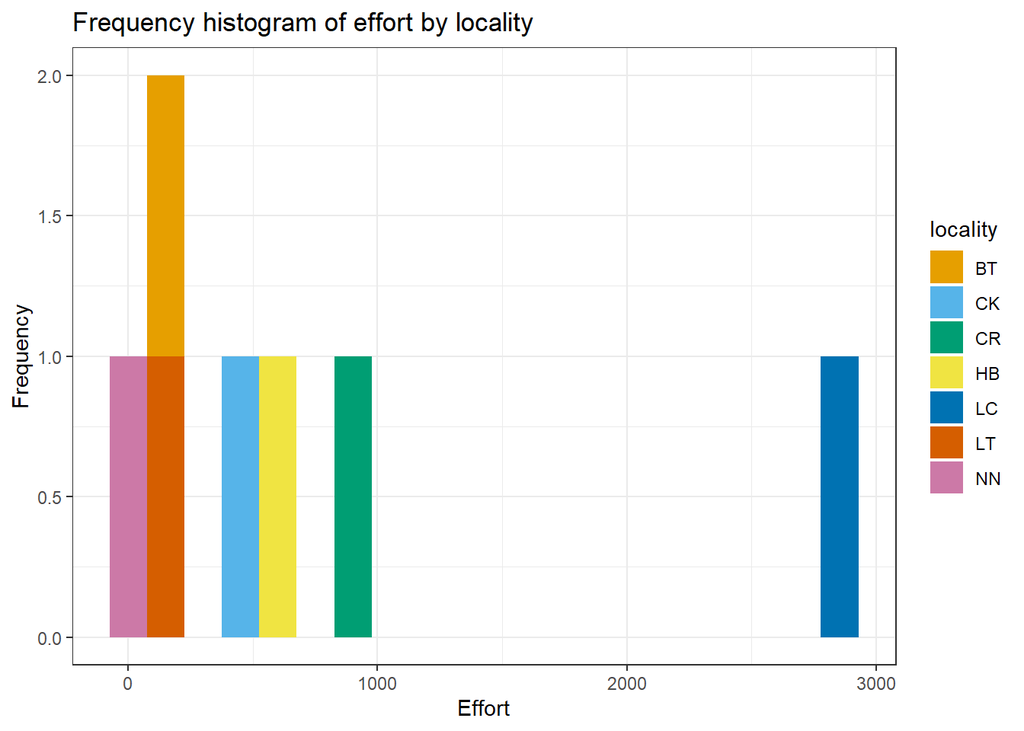

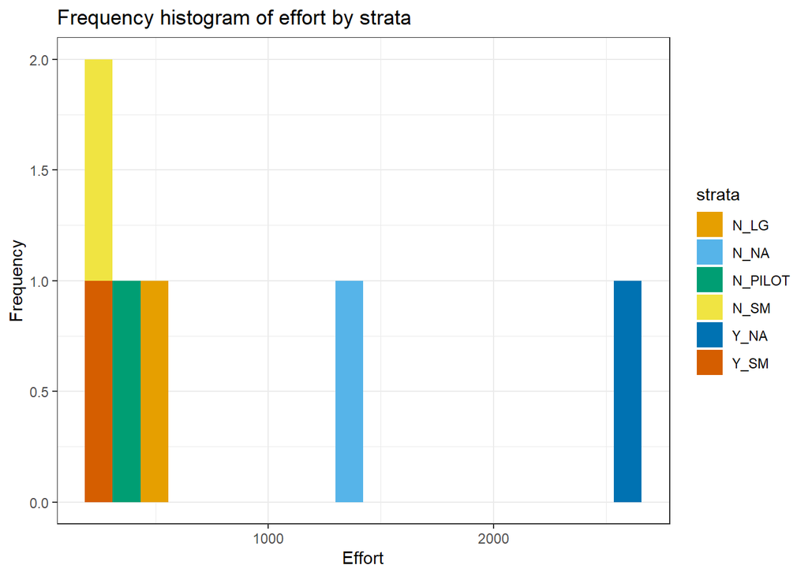

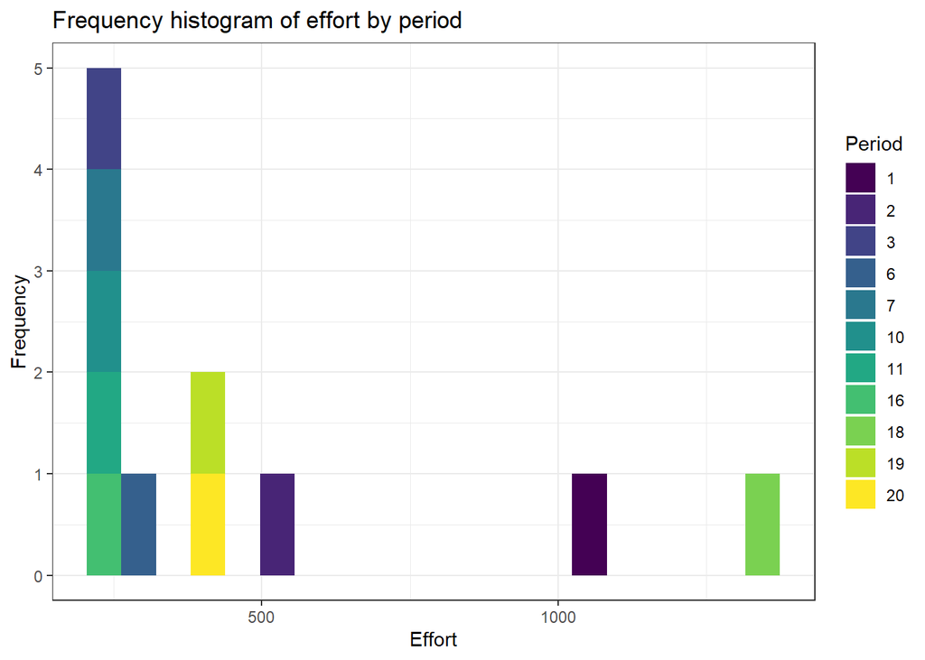

## Summary Tables

These summaries display total counts of live oysters by locality, strata, and period.

```
[1] "Total Counts Per Locality"
 locality count_live.total count_live.sd
       BT        8762.0000     1261.5902
       CK       22293.0000     1091.2989
       CR       47188.5000     1035.4528
       HB       39674.0000     1043.4502
       LC      104094.5000      783.9842
       LT       10621.0000      801.6566
       NN        2380.5000      300.2271

[1] "Total Counts Per Strata"
  strata count_live.total count_live.sd
    N_LG       13037.0000      590.2345
    N_NA       74873.0000      855.3088
 N_PILOT       13237.0000      617.8435
    N_SM       11761.5000     1496.9988
    Y_NA      120239.5000      937.3639
    Y_SM        1865.5000      217.9340

[1] "Total Counts Period"
 period count_live.total count_live.sd
      1      58957.50000    1287.60691
      2      25805.00000     943.02789
      3      17705.00000     813.63167
      6      13412.00000     527.23927
      7        404.00000      56.44719
     10       9659.00000     702.57309
     11       7089.00000     678.01800
     16       3950.00000     466.74886
     18      59925.50000     935.27179
     19      19423.00000     573.08935
     20      18683.50000     689.39925
```

## Plots

Figures displayed include histograms, box plots, and scatter plots for all transect sampling.

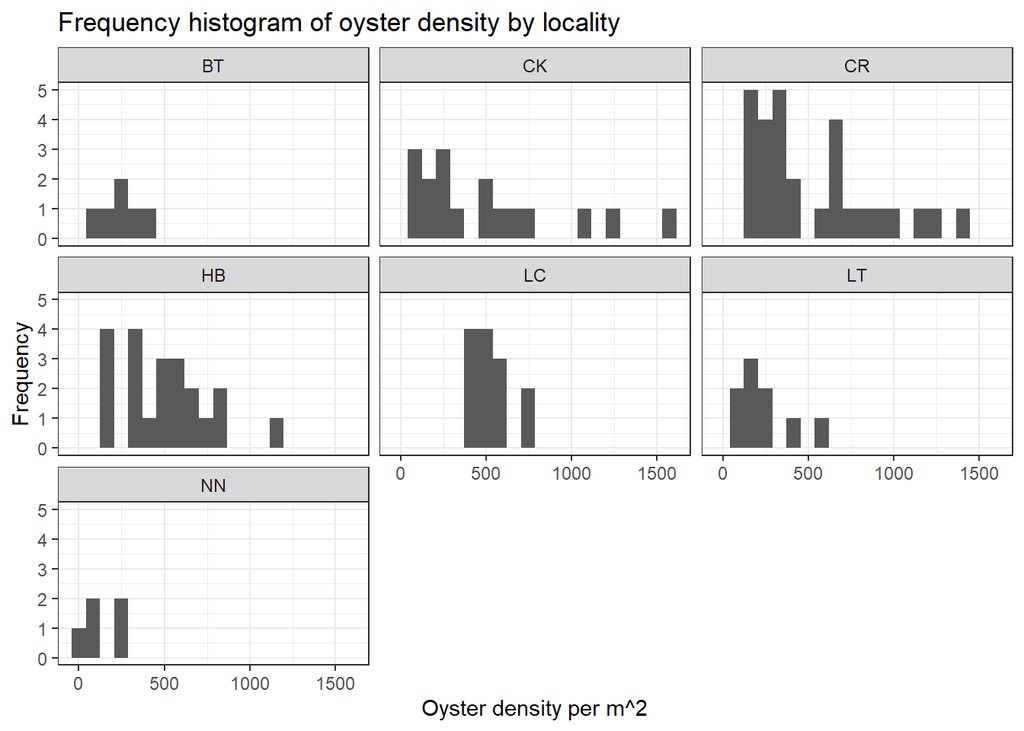

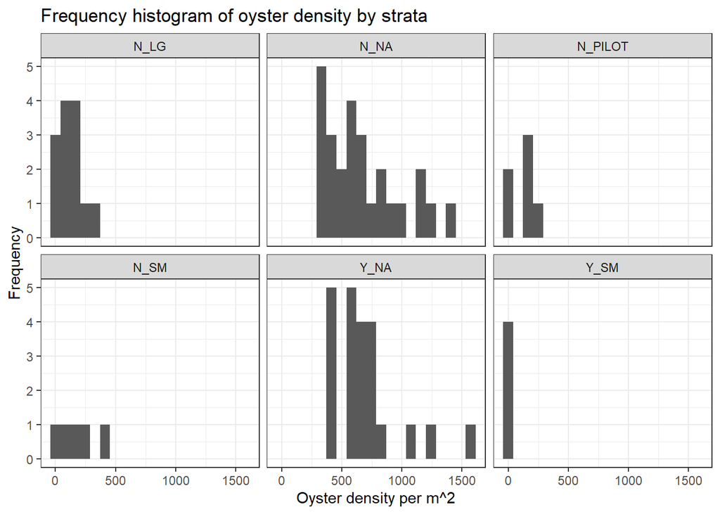

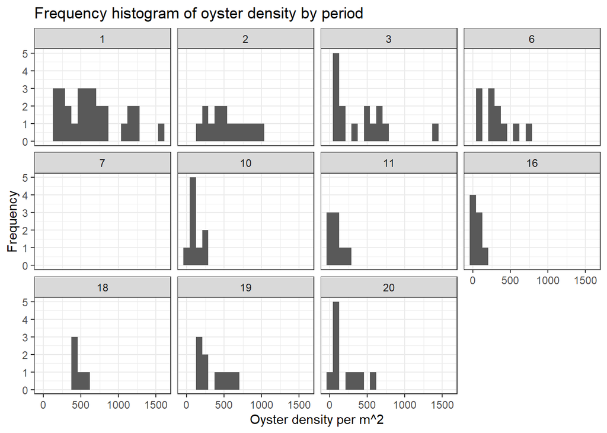

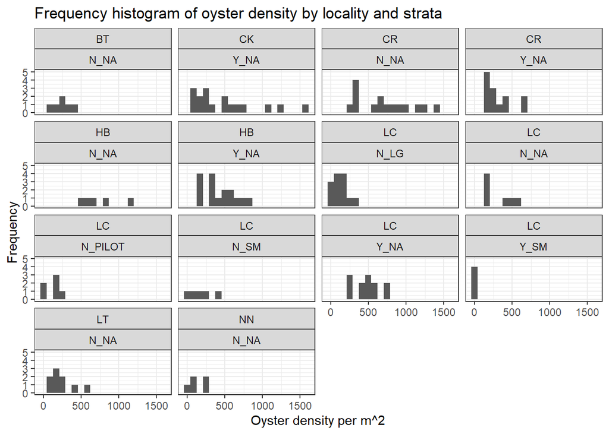

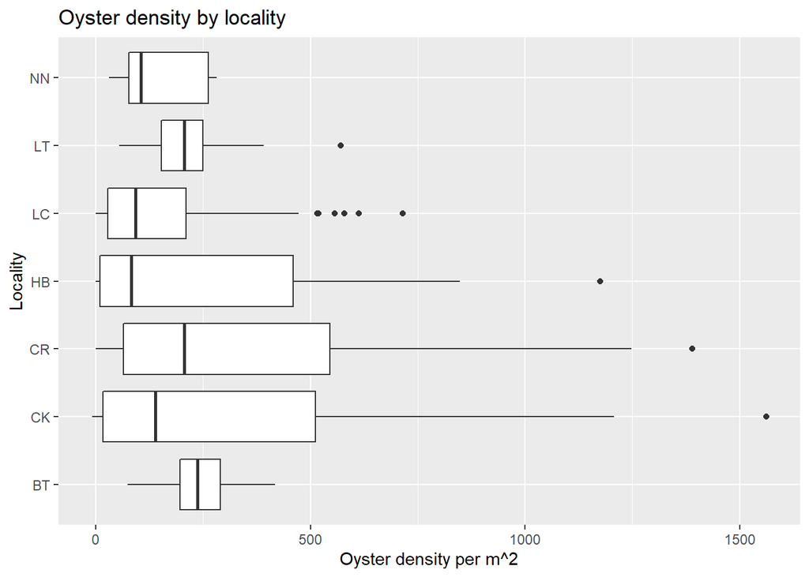

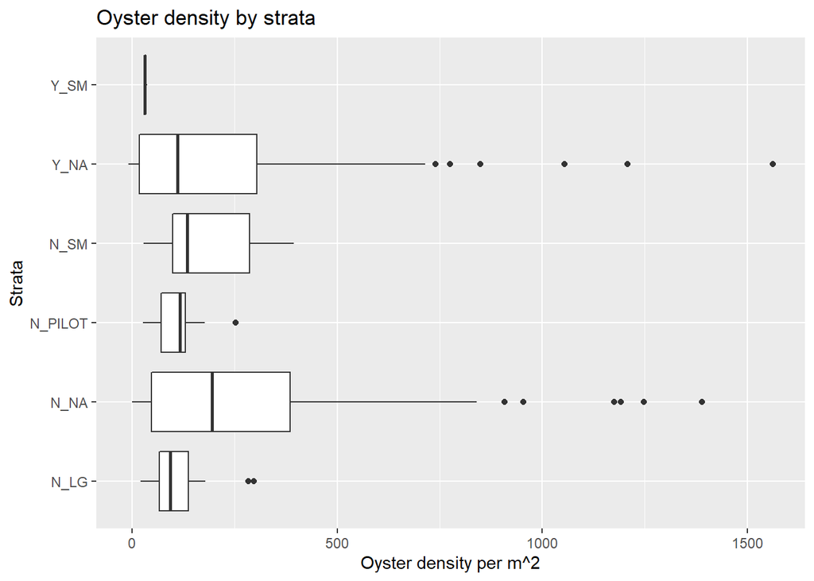

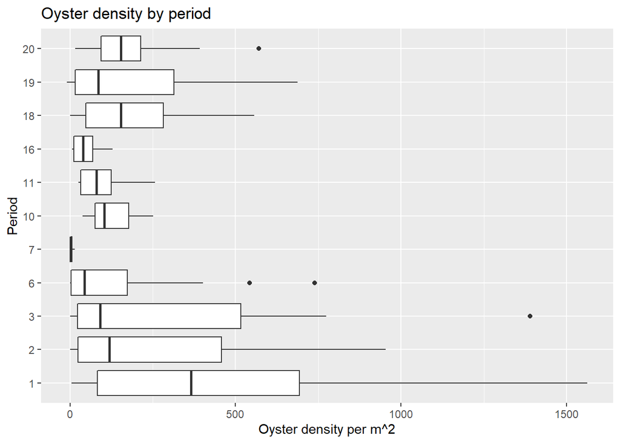

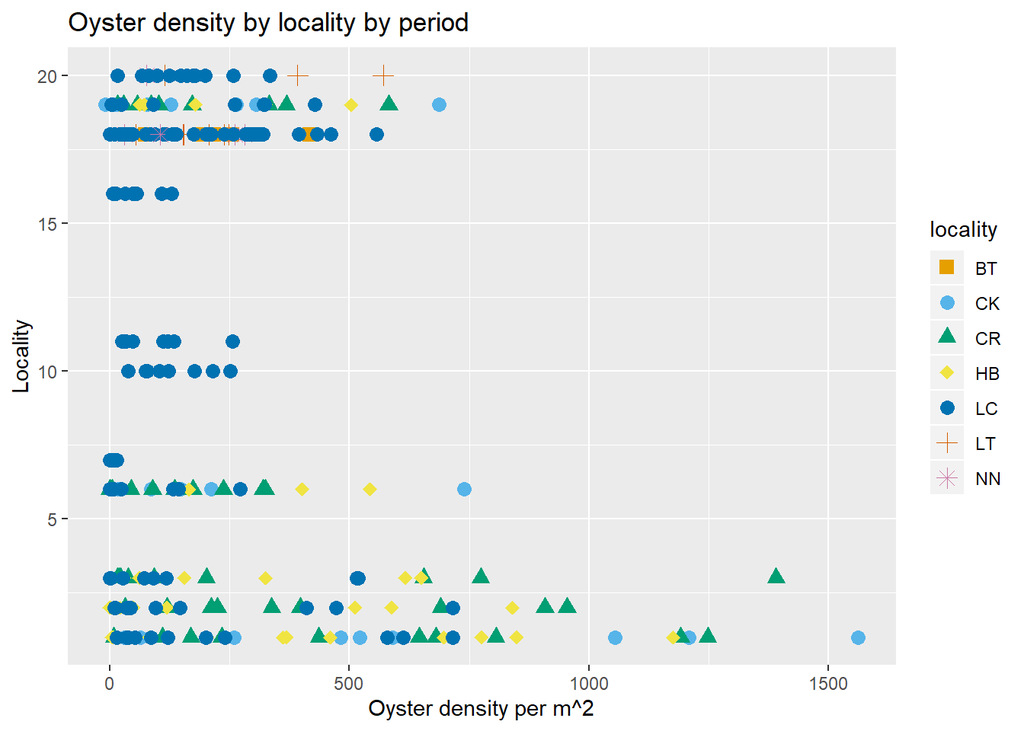

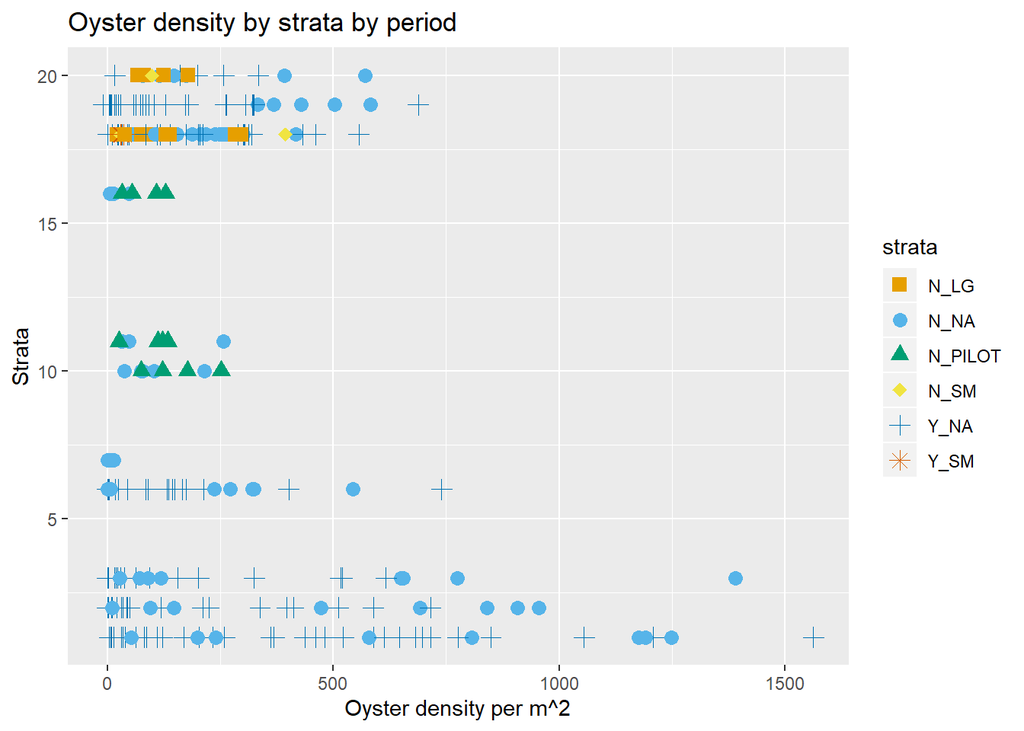

## Pilot Sites

These are figures for oyster counts and oyster density for stations LCO10B, LCO11A, LCO8B, LCO9A.

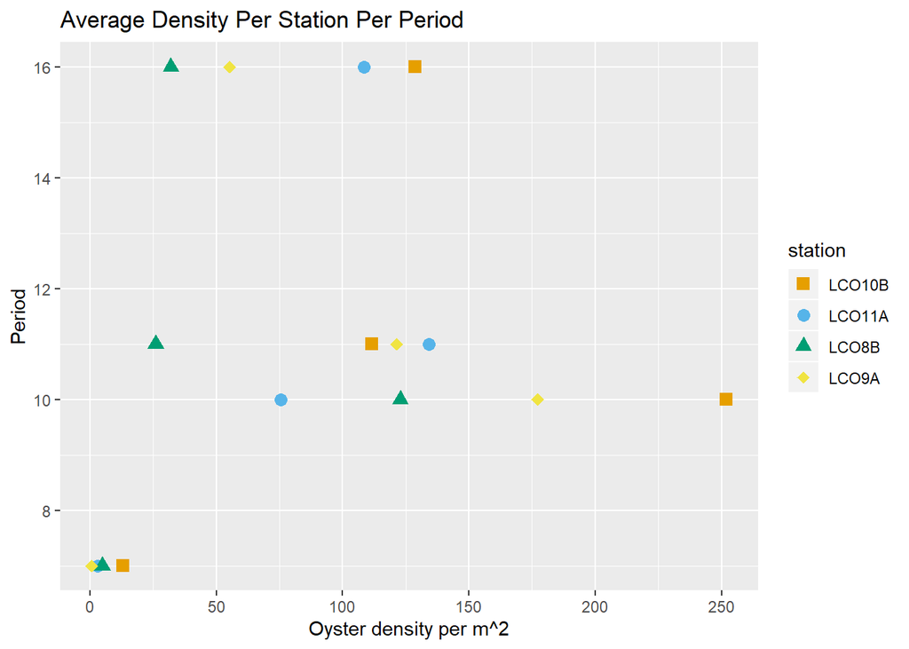

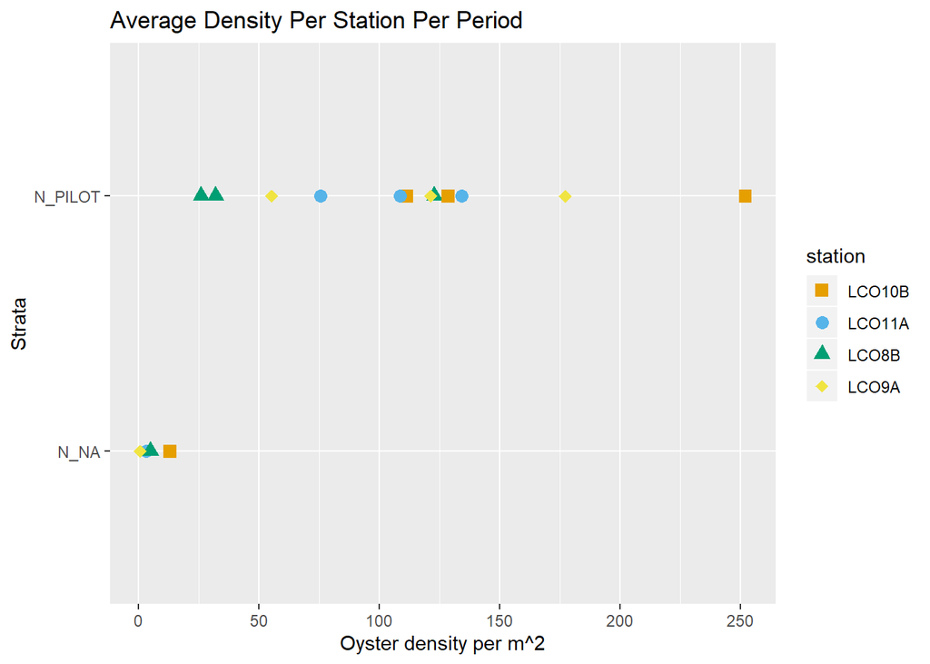

## Progress Bar

The progress bar displays the percentage of the transect sampling progress in relation to the power analysis objective for the current period.

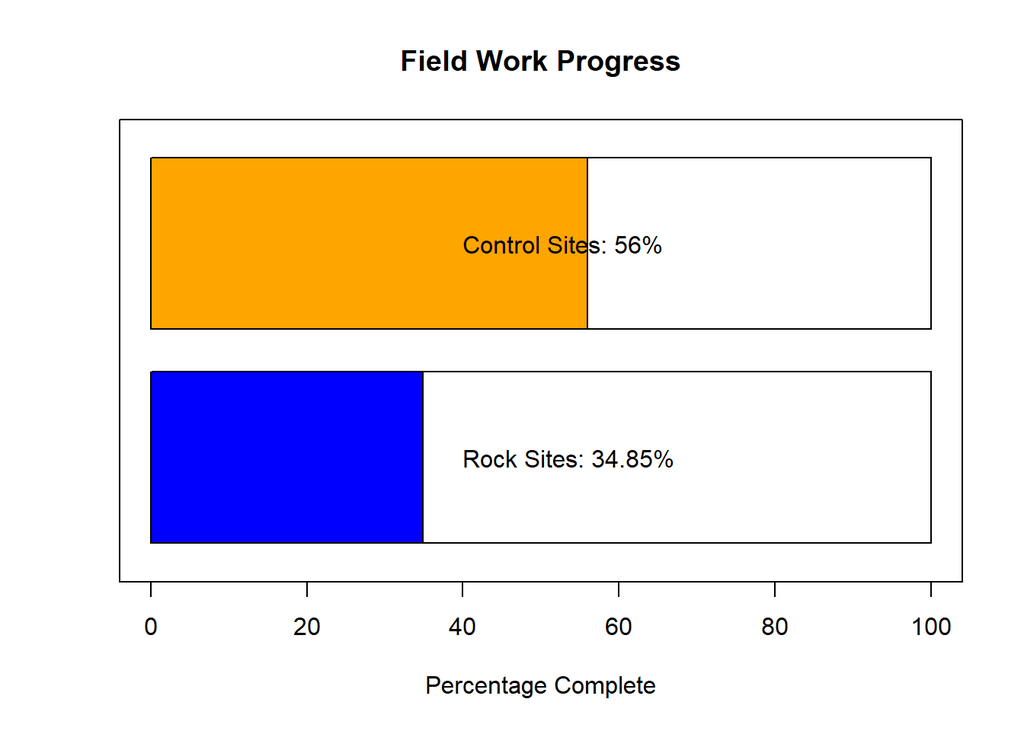

## Latest data entered

Displayed are the entries for the last date of sampling.

```
       date station tran_length count_live count_dead treatment strata
 2019-11-15    LTI8         2.5        153         11   control   N_NA
 2019-11-15    LTI8         5.0        185         28   control   N_NA
 2019-11-15    LTI8         7.5        207         31   control   N_NA
 2019-11-15    LTI8        10.0        221         27   control   N_NA
 2019-11-15    LTI8        12.5        228         42   control   N_NA
 2019-11-15    LTI8        15.0        224         52   control   N_NA
 2019-11-15    LTI8        17.5        219         38   control   N_NA
 2019-11-15    LTI8        20.0        301         50   control   N_NA
 2019-11-15    LTI8        22.5        280         35   control   N_NA
 2019-11-15    LTI8        25.0        282         51   control   N_NA
 2019-11-15    LTI8        27.5        139         22   control   N_NA
 2019-11-15    LTI8        30.0        141         27   control   N_NA
 2019-11-15    LTI8        32.0        203         28   control   N_NA
 2019-11-15    LTI9         2.5         52          6   control   N_NA
 2019-11-15    LTI9         5.0         49          2   control   N_NA
 2019-11-15    LTI9         7.5         37          1   control   N_NA
 2019-11-15    LTI9        10.0         54          9   control   N_NA
 2019-11-15    LTI9        12.5         50          2   control   N_NA
 2019-11-15    LTI9        15.0         55          2   control   N_NA
 2019-11-15    LTI9        17.5         78          4   control   N_NA
 2019-11-15    LTI9        20.0         76          3   control   N_NA
 2019-11-15    LTI9        22.5         59          3   control   N_NA
 2019-11-15    LTI9        25.0         30          1   control   N_NA
 2019-11-15    LTI9        27.5         38          2   control   N_NA
 2019-11-15    LTI9        30.0         60          3   control   N_NA
 2019-11-15    LTI9        32.5         39          2   control   N_NA
 2019-11-15    LTI9        35.0         11          0   control   N_NA
 2019-11-15    LTI9        37.5         25          0   control   N_NA
 2019-11-15    LTI9        40.0         12          0   control   N_NA
 2019-11-15    LTI9        42.5         25          2   control   N_NA
 2019-11-15    LTI9        42.8          0          0   control   N_NA
 2019-11-15    NNI3         2.5         10          0   control   N_NA
 2019-11-15    NNI3         5.0         17          2   control   N_NA
 2019-11-15    NNI3         7.5         10          1   control   N_NA
 2019-11-15    NNI3        10.0         33          3   control   N_NA
 2019-11-15    NNI3        12.5         76          6   control   N_NA
 2019-11-15    NNI3        15.0         19          1   control   N_NA
 2019-11-15    NNI3        17.5         19          1   control   N_NA
 2019-11-15    NNI3        20.0         40          3   control   N_NA
 2019-11-15    NNI3        22.5         39          1   control   N_NA
 2019-11-15    NNI3        25.0         18          1   control   N_NA
 2019-11-15    NNI3        27.5         20          1   control   N_NA
 2019-11-15    NNI3        30.0         12          0   control   N_NA
 2019-11-15    NNI3        32.5         64          3   control   N_NA
 2019-11-15    NNI3        35.0         42          1   control   N_NA
 2019-11-15    NNI3        37.5         20          2   control   N_NA
 2019-11-15    NNI3        40.0         30          3   control   N_NA
 2019-11-15    NNI3        42.5         32          0   control   N_NA
 2019-11-15    NNI3        43.1          8          0   control   N_NA
```